# Data Science 3: Homework Assignment 2

Patrik Szigeti

04/11/2020

# 1. Fashion MNIST data

```r
fashion_mnist <- dataset_fashion_mnist()
x_train <- fashion_mnist$train$x
y_train <- fashion_mnist$train$y
x_test <- fashion_mnist$test$x
y_test <- fashion_mnist$test$y
```

### a. Show some example images from the data.

[figure not shown]

```r
show_mnist_image <- function(x) {
  image(1:28, 1:28, t(x)[,nrow(x):1], col=gray((0:255)/255))
}

show_mnist_image(x_train[1, , ])
```

[figure not shown]

```r
show_mnist_image(x_train[50, , ])
```

[figure not shown]

```r
show_mnist_image(x_train[100, , ])
```

- The first picture in the train data seems to be a shoe.
- The 50th looks like a dress.
- The 100th is a bag.

> Our goal is to have the best possible classifier based on accuracy for these fashion items.

### b. Train a fully connected deep network to predict items.

The images have 28x28 pixel dimensions, and there are 10 different classes in the dataset.

```r
# Reshape train/test inputs
x_train <- array_reshape(x_train, c(dim(x_train)[1], 784))
x_test <- array_reshape(x_test, c(dim(x_test)[1], 784))

# Rescale RGB values into [0, 1]
x_train <- x_train / 255
x_test <- x_test / 255

# One-hot encoding of the target variable
y_train <- to_categorical(y_train, 10)
y_test <- to_categorical(y_test, 10)
```

- As a baseline, I ran the exact same model that we used for digit classification in the class.

```r
model_1 <- keras_model_sequential() %>%
  layer_dense(units = 128, activation = "relu", input_shape = c(784)) %>%
  layer_dropout(rate = 0.3) %>%
  layer_dense(units = 10, activation = "softmax")

model_1 %>% compile(
  loss = "categorical_crossentropy",
  optimizer = optimizer_rmsprop(),
  metrics = c("accuracy")
)

set.seed(1234)
history_1 <- model_1 %>%
  fit(
    x_train, y_train,
    epochs = 30,
    batch_size = 128,
    validation_split = 0.2,
    verbose = FALSE
  )

score_1 <- model_1 %>%
  evaluate(
    x_test, y_test,
    verbose = 0
  )

print(paste("Accuracy of model_1:", round(score_1$accuracy, 4)))
```

```
## [1] "Accuracy of model_1: 0.8869"
```

- For my second model, as the accuracy of the baseline model is pretty promising, I’m keeping everything intact except for the dropout ratio, which I’ll increase to 0.5.

```r
model_2 <- keras_model_sequential() %>%
  layer_dense(units = 128, activation = "relu", input_shape = c(784)) %>%
  layer_dropout(rate = 0.5) %>%
  layer_dense(units = 10, activation = "softmax")

model_2 %>% compile(
  loss = "categorical_crossentropy",
  optimizer = optimizer_rmsprop(),
  metrics = c("accuracy")
)

set.seed(1234)
history_2 <- model_2 %>%
  fit(
    x_train, y_train,
    epochs = 30,
    batch_size = 128,
    validation_split = 0.2,
    verbose = FALSE
  )

score_2 <- model_2 %>%
  evaluate(
    x_test, y_test,
    verbose = 0
  )

print(paste("Accuracy of model_2:", round(score_2$accuracy, 4)))
```

```
## [1] "Accuracy of model_2: 0.8753"
```

- Given that the accuracy didn’t increase, I’m reverting back to my original dropout ratio, and I’ll try adding a third dense layer between the current ones.

```r
model_3 <- keras_model_sequential() %>%
  layer_dense(units = 128, activation = "relu", input_shape = c(784)) %>%
  layer_dropout(rate = 0.3) %>%
  layer_dense(units = 64, activation = "relu", input_shape = c(784)) %>%
  layer_dropout(rate = 0.3) %>%
  layer_dense(units = 10, activation = "softmax")

model_3 %>% compile(
  loss = "categorical_crossentropy",
  optimizer = optimizer_rmsprop(),
  metrics = c("accuracy")
)

set.seed(1234)
history_3 <- model_3 %>%
  fit(
    x_train, y_train,
    epochs = 30,
    batch_size = 128,
    validation_split = 0.2,
    verbose = FALSE
  )

score_3 <- model_3 %>%
  evaluate(
    x_test, y_test,
    verbose = 0
  )

print(paste("Accuracy of model_3:", round(score_3$accuracy, 4)))
```

```
## [1] "Accuracy of model_3: 0.8841"
```

- For my fourth model, I’m experimenting with `tanh` activation instead of `relu` and decreasing the dropout rate to 0.2.

```r
model_4 <- keras_model_sequential() %>%
  layer_dense(units = 128, activation = "tanh", input_shape = c(784)) %>%
  layer_dropout(rate = 0.2) %>%
  layer_dense(units = 10, activation = "softmax")

model_4 %>% compile(
  loss = "categorical_crossentropy",
  optimizer = optimizer_rmsprop(),
  metrics = c("accuracy")
)

set.seed(1234)
history_4 <- model_4 %>%
  fit(
    x_train, y_train,
    epochs = 30,
    batch_size = 128,
    validation_split = 0.2,
    verbose = FALSE
  )

score_4 <- model_4 %>%
  evaluate(
    x_test, y_test,
    verbose = 0
  )

print(paste("Accuracy of model_4:", round(score_4$accuracy, 4)))
```

```
## [1] "Accuracy of model_4: 0.881"
```

- For my fifth and final model, I’m using `adam` as the optimizer instead of `rmsprop` (based on Sebastian Ruder’s [article](https://ruder.io/optimizing-gradient-descent/index.html) about gradient descent optimization algorithms) while keeping `tanh` as the activation function and increasing the dropout ratio to 0.3.

```r
model_5 <- keras_model_sequential() %>%
  layer_dense(units = 128, activation = "tanh", input_shape = c(784)) %>%
  layer_dropout(rate = 0.3) %>%
  layer_dense(units = 10, activation = "softmax")

model_5 %>% compile(
  loss = "categorical_crossentropy",
  optimizer = "adam",
  metrics = c("accuracy")
)

set.seed(1234)
history_5 <- model_5 %>%
  fit(
    x_train, y_train,
    epochs = 30,
    batch_size = 128,
    validation_split = 0.2,
    verbose = FALSE
  )

score_5 <- model_5 %>%
  evaluate(
    x_test, y_test,
    verbose = 0
  )

print(paste("Accuracy of model_5:", round(score_5$accuracy, 4)))
```

```
## [1] "Accuracy of model_5: 0.879"
```

- Evaluate the models

```r
as_tibble(
  list(
    "model_1" = score_1$accuracy,
    "model_2" = score_2$accuracy,
    "model_3" = score_3$accuracy,
    "model_4" = score_4$accuracy,
    "model_5" = score_5$accuracy
  )
)
```

```
## # A tibble: 1 x 5
##   model_1 model_2 model_3 model_4 model_5
##     <dbl>   <dbl>   <dbl>   <dbl>   <dbl>
## 1   0.887   0.875   0.884   0.881   0.879
```

**As my final modeling, I’ve decided to go with my first one, as that produced the highest accuracy.**

```r
final_model <- model_1
final_history <- history_1
```

### c. Evaluate the model on the test set. How does test error compare to validation error?

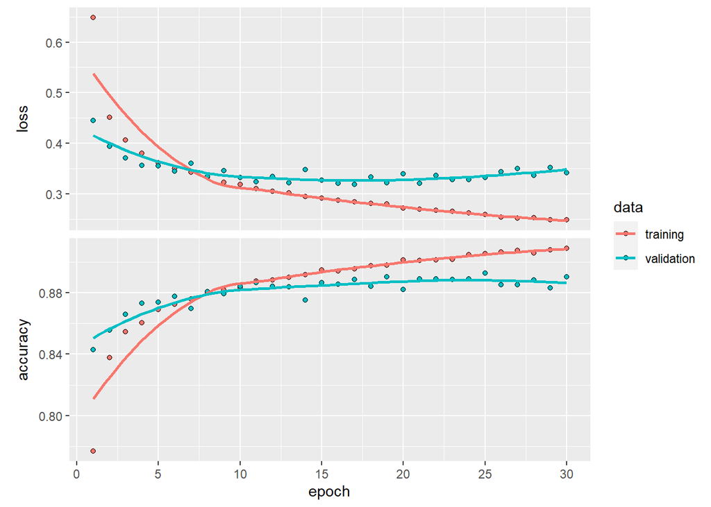

```r
plot(final_history)
```

### d. Try building a convolutional neural network and see if you can improve test set performance.

```r
# Load Fashion MNIST data
x_train_cnn <- fashion_mnist$train$x
y_train_cnn <- fashion_mnist$train$y
x_test_cnn <- fashion_mnist$test$x
y_test_cnn <- fashion_mnist$test$y

# Reshape train/test inputs
x_train_cnn <- array_reshape(x_train_cnn, c(nrow(x_train_cnn), 28, 28, 1))
x_test_cnn <- array_reshape(x_test_cnn, c(nrow(x_test_cnn), 28, 28, 1))

# Rescale RGB values into [0, 1]
x_train_cnn <- x_train_cnn / 255
x_test_cnn <- x_test_cnn / 255

# One-hot encoding of the target variable
y_train_cnn <- to_categorical(y_train_cnn, 10)
y_test_cnn <- to_categorical(y_test_cnn, 10)
```

- Learning from the previous example, I’m once again using the same model we did in class for digit classification as my baseline model. Although I’m decreasing the number of epochs to 15 for two reasons:
  - That seemed to be the cutoff point in case of the fully connected deep network
  - And to limit the computational power needed to run the models.

```r
cnn_model_1 <- keras_model_sequential() %>%
  layer_conv_2d(
    filters = 32,
    kernel_size = c(3, 3),
    activation = "relu",
    input_shape = c(28, 28, 1)
  ) %>%
  layer_max_pooling_2d(pool_size = c(2, 2)) %>%
  layer_dropout(rate = 0.25) %>%
  layer_flatten() %>%
  layer_dense(units = 32, activation = "relu") %>%
  layer_dense(units = 10, activation = "softmax")

cnn_model_1 %>% compile(
  loss = "categorical_crossentropy",
  optimizer = optimizer_rmsprop(),
  metrics = c("accuracy")
)

set.seed(1234)
cnn_history_1 <- cnn_model_1 %>%
  fit(
    x_train_cnn, y_train_cnn,
    epochs = 15,
    batch_size = 128,
    validation_split = 0.2,
    verbose = FALSE
  )

cnn_score_1 <- cnn_model_1 %>%
  evaluate(
    x_test_cnn, y_test_cnn,
    verbose = 0
  )

print(paste("Accuracy of cnn_model_1:", round(cnn_score_1$accuracy, 4)))
```

```
## [1] "Accuracy of cnn_model_1: 0.9072"
```

- For my second model, I’m including an extra convulational layer before `max_pooling_2d` and increasing the number of units in the penultimate dense layer to 128, which was the batch size for the fully connected neural network above.

```r
cnn_model_2 <- keras_model_sequential() %>%
  layer_conv_2d(
    filters = 32,
    kernel_size = c(3, 3),
    activation = "relu",
    input_shape = c(28, 28, 1)
  ) %>%
  layer_conv_2d(
    filters = 64,
    kernel_size = c(3, 3),
    activation = "relu"
  ) %>%
  layer_max_pooling_2d(pool_size = c(2, 2)) %>%
  layer_dropout(rate = 0.25) %>%
  layer_flatten() %>%
  layer_dense(units = 128, activation = "relu") %>%
  layer_dense(units = 10, activation = "softmax")

cnn_model_2 %>% compile(
  loss = "categorical_crossentropy",
  optimizer = optimizer_rmsprop(),
  metrics = c("accuracy")
)

set.seed(1234)
cnn_history_2 <- cnn_model_2 %>%
  fit(
    x_train_cnn, y_train_cnn,
    epochs = 15,
    batch_size = 128,
    validation_split = 0.2,
    verbose = FALSE
  )

cnn_score_2 <- cnn_model_2 %>%
  evaluate(
    x_test_cnn, y_test_cnn,
    verbose = 0
  )

print(paste("Accuracy of cnn_model_2:", round(cnn_score_2$accuracy, 4)))
```

```
## [1] "Accuracy of cnn_model_2: 0.9201"
```

- For my third and final model, as my previous models are already above 90% in accuracy, I’m just slightly refining them by adding a dropout layer with `rate = 0.5` between the two dense layers. I’m also trying `adadelta` as the optimizer, which has parameter-specific learning rates that are adapted relative to how frequently a parameter gets updated during training (idea based on Roan Gylberth’s [article](https://medium.com/konvergen/continuing-on-adaptive-method-adadelta-and-rmsprop-1ff2c6029133)).

```r
cnn_model_3 <- keras_model_sequential() %>%
  layer_conv_2d(
    filters = 32,
    kernel_size = c(3, 3),
    activation = "relu",
    input_shape = c(28, 28, 1)
  ) %>%
  layer_conv_2d(
    filters = 64,
    kernel_size = c(3, 3),
    activation = "relu"
  ) %>%
  layer_max_pooling_2d(pool_size = c(2, 2)) %>%
  layer_dropout(rate = 0.25) %>%
  layer_flatten() %>%
  layer_dense(units = 128, activation = "relu") %>%
  layer_dropout(rate = 0.5) %>%
  layer_dense(units = 10, activation = "softmax")

cnn_model_3 %>% compile(
  loss = "categorical_crossentropy",
  optimizer = optimizer_adadelta(),
  metrics = c("accuracy")
)

set.seed(1234)
cnn_history_3 <- cnn_model_3 %>%
  fit(
    x_train_cnn, y_train_cnn,
    epochs = 15,
    batch_size = 128,
    validation_split = 0.2,
    verbose = FALSE
  )

cnn_score_3 <- cnn_model_3 %>%
  evaluate(
    x_test_cnn, y_test_cnn,
    verbose = 0
  )

print(paste("Accuracy of cnn_model_3:", round(cnn_score_3$accuracy, 4)))
```

```
## [1] "Accuracy of cnn_model_3: 0.9209"
```

- Compare test accuracy for the three convolutional neural network models

```r
as_tibble(
  list(
    "cnn_model_1" = cnn_score_1$accuracy,
    "cnn_model_2" = cnn_score_2$accuracy,
    "cnn_model_3" = cnn_score_3$accuracy
  )
)
```

```
## # A tibble: 1 x 3
##   cnn_model_1 cnn_model_2 cnn_model_3
##         <dbl>       <dbl>       <dbl>
## 1       0.907       0.920       0.921
```

**All three convolutional models improved test performance** compared to the fully connected models, and it seems like adding an extra convolutional layer really helped increase performance, there’s an apparent step between `cnn_model_1` and `cnn_model_2`. Including an additional dropout layer (`cnn_model_3`) didn’t add too much value.

# 2. Hor dog or not hot dog?

### a. Pre-process data so that it is acceptable by Keras (set folder structure, bring images to the same size, etc).

- Looking at one example with the folder structure set up correctly to train/test and hot_dog/not_hot_dog:

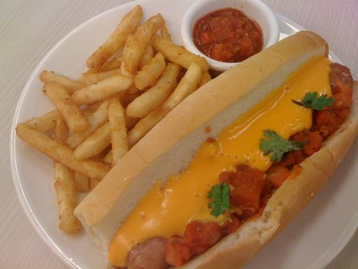

```r
example_image_path <- file.path(here(), "/data/hot-dog-not-hot-dog/train/hot_dog/124323.jpg")

image_read(example_image_path)
```

- Pre-processing the data

```r
# Normalize the inputs by rescaling
train_datagen <- image_data_generator(rescale = 1/255)
test_datagen <- image_data_generator(rescale = 1/255)

image_size <- c(300, 300) # Resize all images to 300x300 pixels
batch_size <- 32

train_generator <- flow_images_from_directory(
  file.path(here(), "data/hot-dog-not-hot-dog/train/"),
  train_datagen,
  target_size = image_size,
  batch_size = batch_size,
  class_mode = "binary"
)

test_generator <- flow_images_from_directory(
  file.path(here(), "data/hot-dog-not-hot-dog/test/"),
  test_datagen,
  target_size = image_size,
  batch_size = batch_size,
  class_mode = "binary"
)
```

### b. Estimate a convolutional neural network to predict if an image contains a hot dog or not. Evaluate your model on the test set.

```r
hot_dog_model <- keras_model_sequential() %>%
  layer_conv_2d(
    filters = 32,
    kernel_size = c(3, 3),
    activation = 'relu',
    input_shape = c(300, 300, 3)
  ) %>%
  layer_max_pooling_2d(pool_size = c(2, 2)) %>%
  layer_conv_2d(
    filters = 32,
    kernel_size = c(3, 3),
    activation = "relu"
  ) %>%
  layer_max_pooling_2d(pool_size = c(3, 3)) %>%
  layer_dropout(rate = 0.25) %>%
  layer_conv_2d(
    filters = 64,
    kernel_size = c(3, 3),
    activation = 'relu') %>%
  layer_max_pooling_2d(pool_size = c(2, 2)) %>%
  layer_dropout(rate = 0.5) %>%
  layer_flatten() %>%
  layer_dense(units = 128, activation = "relu") %>%
  layer_dropout(rate = 0.5) %>%
  layer_dense(units = 1, activation = "sigmoid")

hot_dog_model %>% compile(
  loss = "binary_crossentropy",
  optimizer = optimizer_rmsprop(lr = 2e-5),
  metrics = c("accuracy")
)

set.seed(1234)
hot_dog_history <- hot_dog_model %>%
  fit_generator(
    train_generator,
    steps_per_epoch = 2000 / batch_size,
    epochs = 15,
    validation_data = test_generator,
    validation_steps = 50,
    verbose = 0
  )
```

```r
print(paste("Accuracy of the convolutional neural network on the test set:", round(max(hot_dog_history$metrics$val_accuracy), 4)))
```

```
## [1] "Accuracy of the convolutional neural network on the test set: 0.5563"
```

With the convolutional neural network, I was able to achieve accuracy that is a little better than a coin toss, but unfortunately I'm stretching the limits of my machine's computational capabilities.

### c. Could data augmentation techniques help with achieving higher predictive accuracy? Try some augmentations that you think make sense and compare.

- Modify `train_datagen` with augmentation techniques

```r
train_datagen_aug <- image_data_generator(
  rescale = 1/255,
  rotation_range = 40,
  width_shift_range = 0.2,
  height_shift_range = 0.2,
  shear_range = 0.2,
  channel_shift_range = 0.2,
  zoom_range = 0.1,
  horizontal_flip = TRUE,
  fill_mode = "nearest"
)

train_generator_aug <- flow_images_from_directory(
  file.path(here(), "data/hot-dog-not-hot-dog/train/"),
  train_datagen_aug,
  target_size = image_size,
  batch_size = batch_size,
  class_mode = "binary"
)
```

- Run and evaluate the same model from before with augmented data

```r
set.seed(1234)
hot_dog_history_aug <- hot_dog_model %>%
  fit_generator(
    train_generator_aug,
    steps_per_epoch = 2000 / batch_size,
    epochs = 15,
    validation_data = test_generator,
    validation_steps = 50,
    verbose = 0
  )

print(paste("Accuracy on the test set with augmented data:", round(max(hot_dog_history_aug$metrics$val_accuracy), 4)))
```

```
## [1] "Accuracy on the test set with augmented data: 0.571"
```

It seems like data augmentation techniques do help with achieving higher predictive accuracy, but only by a small margin.

### d. Try to rely on some pre-built neural networks to aid prediction. Can you achieve a better performance using transfer learning for this problem?

For this exercise, I’m going to use the same augmented `train_generator_aug` as before, and my custom layers are two dense layers with a dropout layer with `rate = 0.5` between them.

```r
# Create the base pre-trained model
tl_base_model <- application_mobilenet(
  weights = "imagenet",
  include_top = FALSE,
  input_shape = c(image_size, 3)
)

# Freeze all convolutional mobilenet layers
freeze_weights(tl_base_model)

# Add custom layers
tl_predictions <- tl_base_model$output %>%
  layer_global_average_pooling_2d() %>%
  layer_dense(units = 128, activation = "relu") %>%
  layer_dropout(rate = 0.5) %>%
  layer_dense(units = 1, activation = "sigmoid")

# Compile the train model
tl_model <- keras_model(
  inputs = tl_base_model$input,
  outputs = tl_predictions
)

tl_model %>% compile(
  loss = "binary_crossentropy",
  optimizer = optimizer_rmsprop(lr = 2e-5),
  metrics = c("accuracy")
)

# Train the model
tl_history <- tl_model %>%
  fit_generator(
    train_generator_aug,
    steps_per_epoch = 2000 / batch_size,
    epochs = 1,
    validation_data = test_generator,
    validation_steps = 50
  )

print(paste("Accuracy on the test set with transfer learning:", round(max(tl_history$metrics$val_accuracy), 4)))
```

```
## [1] "Accuracy on the test set with transfer learning: 0.601"
```

I could achieve a better result with transfer learning with as few as 1 epochs, which means with more computational power, I would be able to predict whether a picture shows a hot dog or not a lot better. Again, unfortunately my capabilities are limited, but the gains of transfer learning are already apparent from this small example.